```python
import numpy as np
import pandas as pd
import matplotlib.pyplot as plt
import seaborn as sns
from scipy.spatial.distance import pdist
from math import ceil
%matplotlib inline
df = pd.read_csv("Game/vgsales.csv",encoding="utf-8")
```

# 分析数据库信息并进行挖掘

```python
df.head()
```

|  | Rank | Name | Platform | Year | Genre | Publisher | NA_Sales | EU_Sales | JP_Sales | Other_Sales | Global_Sales |
| --- | --- | --- | --- | --- | --- | --- | --- | --- | --- | --- | --- |
| 0 | 1 | Wii Sports | Wii | 2006.0 | Sports | Nintendo | 41.49 | 29.02 | 3.77 | 8.46 | 82.74 |
| 1 | 2 | Super Mario Bros. | NES | 1985.0 | Platform | Nintendo | 29.08 | 3.58 | 6.81 | 0.77 | 40.24 |
| 2 | 3 | Mario Kart Wii | Wii | 2008.0 | Racing | Nintendo | 15.85 | 12.88 | 3.79 | 3.31 | 35.82 |
| 3 | 4 | Wii Sports Resort | Wii | 2009.0 | Sports | Nintendo | 15.75 | 11.01 | 3.28 | 2.96 | 33.00 |
| 4 | 5 | Pokemon Red/Pokemon Blue | GB | 1996.0 | Role-Playing | Nintendo | 11.27 | 8.89 | 10.22 | 1.00 | 31.37 |

```python
df.info()
df=df.dropna(axis=0, how='any')
df=df.reset_index(drop=True)#index重排序
df.info()
```

```
<class 'pandas.core.frame.DataFrame'>
RangeIndex: 16598 entries, 0 to 16597
Data columns (total 11 columns):
Rank            16598 non-null int64
Name            16598 non-null object
Platform        16598 non-null object
Year            16327 non-null float64
Genre           16598 non-null object
Publisher       16540 non-null object
NA_Sales        16598 non-null float64
EU_Sales        16598 non-null float64
JP_Sales        16598 non-null float64
Other_Sales     16598 non-null float64
Global_Sales    16598 non-null float64
dtypes: float64(6), int64(1), object(4)
memory usage: 1.4+ MB
<class 'pandas.core.frame.DataFrame'>
RangeIndex: 16291 entries, 0 to 16290
Data columns (total 11 columns):
Rank            16291 non-null int64
Name            16291 non-null object
Platform        16291 non-null object
Year            16291 non-null float64
Genre           16291 non-null object
Publisher       16291 non-null object
NA_Sales        16291 non-null float64
EU_Sales        16291 non-null float64
JP_Sales        16291 non-null float64
Other_Sales     16291 non-null float64
Global_Sales    16291 non-null float64
dtypes: float64(6), int64(1), object(4)
memory usage: 1.4+ MB
```

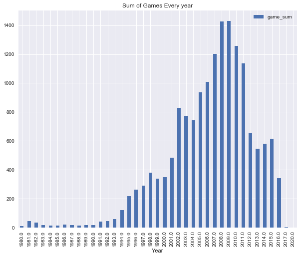

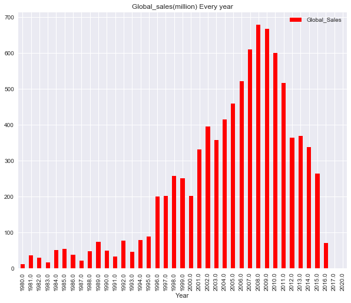

```python
##每年发布的游戏和销量##
Year=df.loc[:,'Year'].value_counts()
index=Year.index.values
Year_sum=Year.values
dic1 = {'Year':index, 'game_sum': Year_sum}
Year_frame=pd.DataFrame(dic1)
Year_frame=Year_frame.sort_values(by="Year")
Year_frame=Year_frame.set_index('Year',drop='true')
plt.figure( )
Year_frame.plot(kind='bar',figsize=(10,8))
plt.title("Sum of Games Every year")
plt.show()

revenue=df[["Year","Global_Sales"]]
revenue=revenue.groupby(by="Year").sum()
fig = plt.figure( )
revenue.plot(kind='bar',figsize=(10,8),color='red')
plt.title("Global_sales(million) Every year")
plt.show()
```

**从上面游戏发布数量和销售额随时间变化可以看出，自1997年之后，发行数量激增，伴随而来的是销量的突飞猛进，并在2008年和2009年达到顶峰。 最近几年开始下降。 这可能和近年来的其他联网大型游戏的制作有关。**

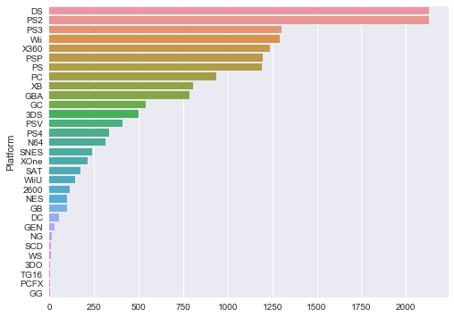

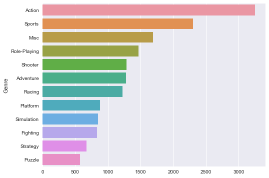

```python
#获取平台发售的数量和销售游戏类型相关信息
platGenre = pd.crosstab(df.Platform,df.Genre)
platGenreTotal = platGenre.sum(axis=1).sort_values(ascending = False)
plt.figure(figsize=(8,6))

sns.barplot(y = platGenreTotal.index, x = platGenreTotal.values, orient='h')
plt.show()

platGenreTotal = platGenre.sum(axis=0).sort_values(ascending = False)
plt.figure(figsize=(8,6))

sns.barplot(y = platGenreTotal.index, x = platGenreTotal.values, orient='h')
plt.show()
```

**最受欢迎的游戏，类型，平台，发行人可以根据销售额的多少来进行反应的，可以从全球，美国，欧洲，日本几个区域类分析**

```python
area_list=["NA_Sales","EU_Sales","JP_Sales","Global_Sales"]
df_show1=pd.DataFrame(columns=['Year' ,'Rank1','Rank2','Rank3','Rank4'])
df_show2=pd.DataFrame(columns=['Year' ,'Rank1','Rank2','Rank3','Rank4'])
df_show3=pd.DataFrame(columns=['Year' ,'Rank1','Rank2','Rank3','Rank4'])
df_show4=pd.DataFrame(columns=['Year' ,'Rank1','Rank2','Rank3','Rank4'])
df_show=[df_show1,df_show2,df_show3,df_show4]
for i in range(4):
    temp=0
    df_area=df[["Year","Genre","Publisher",area_list[i]]]
    for year in range(int(df_area["Year"].min()+1),int(df_area["Year"].max()-3)):
        df_eachyear = df_area[df_area['Year'] == year]
        df_eachyear=df_eachyear[["Publisher",area_list[i]]].groupby(by="Publisher").count().sort_values(by=area_list[i])[::-1]
        df_array=df_eachyear.head(4).index.values

        df_array= np.append(year,df_array)

        df_show[i].loc[temp]=df_array
        temp+=1
```

```python
print("--------------------NA的发行人排名情况(销量前4)---------")

df_show[0].head(int(df_area["Year"].max()-3)-int(df_area["Year"].min()+1))
```

```
--------------------NA的发行人排名情况(销量前4)---------
```

|  | Year | Rank1 | Rank2 | Rank3 | Rank4 |
| --- | --- | --- | --- | --- | --- |
| 0 | 1981 | Atari | Mattel Interactive | Activision | Imagic |
| 1 | 1982 | Atari | Activision | 20th Century Fox Video Games | Parker Bros. |
| 2 | 1983 | Nintendo | Atari | Activision | Parker Bros. |
| 3 | 1984 | Nintendo | Namco Bandai Games | Hudson Soft | Activision |
| 4 | 1985 | Nintendo | Namco Bandai Games | Activision | Mycom |
| 5 | 1986 | Nintendo | Konami Digital Entertainment | Hudson Soft | Capcom |
| 6 | 1987 | Nintendo | Atari | Namco Bandai Games | Activision |
| 7 | 1988 | Nintendo | Namco Bandai Games | Capcom | Activision |
| 8 | 1989 | Nintendo | SquareSoft | Palcom | Namco Bandai Games |
| 9 | 1990 | Nintendo | Capcom | Namco Bandai Games | SquareSoft |
| 10 | 1991 | Nintendo | Konami Digital Entertainment | Imagineer | Capcom |
| 11 | 1992 | Nintendo | Sega | Capcom | Konami Digital Entertainment |
| 12 | 1993 | Nintendo | Namco Bandai Games | Capcom | Sega |
| 13 | 1994 | Sega | Nintendo | Sony Computer Entertainment | Acclaim Entertainment |
| 14 | 1995 | Sony Computer Entertainment | Sega | Konami Digital Entertainment | Electronic Arts |
| 15 | 1996 | Sony Computer Entertainment | Nintendo | Konami Digital Entertainment | Sega |
| 16 | 1997 | Sony Computer Entertainment | Electronic Arts | Konami Digital Entertainment | GT Interactive |
| 17 | 1998 | Electronic Arts | Sony Computer Entertainment | Konami Digital Entertainment | Acclaim Entertainment |
| 18 | 1999 | Konami Digital Entertainment | Electronic Arts | Sony Computer Entertainment | Nintendo |
| 19 | 2000 | Sony Computer Entertainment | Electronic Arts | Konami Digital Entertainment | Nintendo |
| 20 | 2001 | Electronic Arts | Konami Digital Entertainment | Sony Computer Entertainment | THQ |
| 21 | 2002 | Electronic Arts | THQ | Konami Digital Entertainment | Activision |
| 22 | 2003 | Electronic Arts | THQ | Ubisoft | Atari |
| 23 | 2004 | Electronic Arts | Nintendo | THQ | Activision |
| 24 | 2005 | Electronic Arts | Activision | THQ | Ubisoft |
| 25 | 2006 | Electronic Arts | Namco Bandai Games | Konami Digital Entertainment | Ubisoft |
| 26 | 2007 | Electronic Arts | Ubisoft | Activision | THQ |
| 27 | 2008 | Electronic Arts | Ubisoft | Activision | Sega |
| 28 | 2009 | Activision | Electronic Arts | Ubisoft | THQ |
| 29 | 2010 | Activision | Electronic Arts | Ubisoft | Namco Bandai Games |
| 30 | 2011 | Ubisoft | THQ | Electronic Arts | Namco Bandai Games |
| 31 | 2012 | Namco Bandai Games | Electronic Arts | Activision | Ubisoft |
| 32 | 2013 | Namco Bandai Games | Electronic Arts | Activision | Ubisoft |
| 33 | 2014 | Namco Bandai Games | Ubisoft | Activision | Electronic Arts |
| 34 | 2015 | Namco Bandai Games | Activision | Tecmo Koei | Electronic Arts |
| 35 | 2016 | Namco Bandai Games | Electronic Arts | Square Enix | Capcom |

```python
print("--------------------EU的发行人排名情况(销量前4)---------")

df_show[1].head(int(df_area["Year"].max()-3)-int(df_area["Year"].min()+1))
```

```
--------------------EU的发行人排名情况(销量前4)---------
```

|  | Year | Rank1 | Rank2 | Rank3 | Rank4 |
| --- | --- | --- | --- | --- | --- |
| 0 | 1981 | Atari | Mattel Interactive | Activision | Imagic |
| 1 | 1982 | Atari | Activision | 20th Century Fox Video Games | Parker Bros. |
| 2 | 1983 | Nintendo | Atari | Activision | Parker Bros. |
| 3 | 1984 | Nintendo | Namco Bandai Games | Hudson Soft | Activision |
| 4 | 1985 | Nintendo | Namco Bandai Games | Activision | Mycom |
| 5 | 1986 | Nintendo | Konami Digital Entertainment | Hudson Soft | Capcom |
| 6 | 1987 | Nintendo | Atari | Namco Bandai Games | Activision |
| 7 | 1988 | Nintendo | Namco Bandai Games | Capcom | Activision |
| 8 | 1989 | Nintendo | SquareSoft | Palcom | Namco Bandai Games |
| 9 | 1990 | Nintendo | Capcom | Namco Bandai Games | SquareSoft |
| 10 | 1991 | Nintendo | Konami Digital Entertainment | Imagineer | Capcom |
| 11 | 1992 | Nintendo | Sega | Capcom | Konami Digital Entertainment |
| 12 | 1993 | Nintendo | Namco Bandai Games | Capcom | Sega |
| 13 | 1994 | Sega | Nintendo | Sony Computer Entertainment | Acclaim Entertainment |
| 14 | 1995 | Sony Computer Entertainment | Sega | Konami Digital Entertainment | Electronic Arts |
| 15 | 1996 | Sony Computer Entertainment | Nintendo | Konami Digital Entertainment | Sega |
| 16 | 1997 | Sony Computer Entertainment | Electronic Arts | Konami Digital Entertainment | GT Interactive |
| 17 | 1998 | Electronic Arts | Sony Computer Entertainment | Konami Digital Entertainment | Acclaim Entertainment |
| 18 | 1999 | Konami Digital Entertainment | Electronic Arts | Sony Computer Entertainment | Nintendo |
| 19 | 2000 | Sony Computer Entertainment | Electronic Arts | Konami Digital Entertainment | Nintendo |
| 20 | 2001 | Electronic Arts | Konami Digital Entertainment | Sony Computer Entertainment | THQ |
| 21 | 2002 | Electronic Arts | THQ | Konami Digital Entertainment | Activision |
| 22 | 2003 | Electronic Arts | THQ | Ubisoft | Atari |
| 23 | 2004 | Electronic Arts | Nintendo | THQ | Activision |
| 24 | 2005 | Electronic Arts | Activision | THQ | Ubisoft |
| 25 | 2006 | Electronic Arts | Namco Bandai Games | Konami Digital Entertainment | Ubisoft |
| 26 | 2007 | Electronic Arts | Ubisoft | Activision | THQ |
| 27 | 2008 | Electronic Arts | Ubisoft | Activision | Sega |
| 28 | 2009 | Activision | Electronic Arts | Ubisoft | THQ |
| 29 | 2010 | Activision | Electronic Arts | Ubisoft | Namco Bandai Games |
| 30 | 2011 | Ubisoft | THQ | Electronic Arts | Namco Bandai Games |
| 31 | 2012 | Namco Bandai Games | Electronic Arts | Activision | Ubisoft |
| 32 | 2013 | Namco Bandai Games | Electronic Arts | Activision | Ubisoft |
| 33 | 2014 | Namco Bandai Games | Ubisoft | Activision | Electronic Arts |
| 34 | 2015 | Namco Bandai Games | Activision | Tecmo Koei | Electronic Arts |
| 35 | 2016 | Namco Bandai Games | Electronic Arts | Square Enix | Capcom |

```python
print("--------------------JP的发行人排名情况(销量前4)---------")

df_show[2].head(int(df_area["Year"].max()-3)-int(df_area["Year"].min()+1))
```

```
--------------------JP的发行人排名情况(销量前4)---------
```

|  | Year | Rank1 | Rank2 | Rank3 | Rank4 |
| --- | --- | --- | --- | --- | --- |
| 0 | 1981 | Atari | Mattel Interactive | Activision | Imagic |
| 1 | 1982 | Atari | Activision | 20th Century Fox Video Games | Parker Bros. |
| 2 | 1983 | Nintendo | Atari | Activision | Parker Bros. |
| 3 | 1984 | Nintendo | Namco Bandai Games | Hudson Soft | Activision |
| 4 | 1985 | Nintendo | Namco Bandai Games | Activision | Mycom |
| 5 | 1986 | Nintendo | Konami Digital Entertainment | Hudson Soft | Capcom |
| 6 | 1987 | Nintendo | Atari | Namco Bandai Games | Activision |
| 7 | 1988 | Nintendo | Namco Bandai Games | Capcom | Activision |
| 8 | 1989 | Nintendo | SquareSoft | Palcom | Namco Bandai Games |
| 9 | 1990 | Nintendo | Capcom | Namco Bandai Games | SquareSoft |
| 10 | 1991 | Nintendo | Konami Digital Entertainment | Imagineer | Capcom |
| 11 | 1992 | Nintendo | Sega | Capcom | Konami Digital Entertainment |
| 12 | 1993 | Nintendo | Namco Bandai Games | Capcom | Sega |
| 13 | 1994 | Sega | Nintendo | Sony Computer Entertainment | Acclaim Entertainment |
| 14 | 1995 | Sony Computer Entertainment | Sega | Konami Digital Entertainment | Electronic Arts |
| 15 | 1996 | Sony Computer Entertainment | Nintendo | Konami Digital Entertainment | Sega |
| 16 | 1997 | Sony Computer Entertainment | Electronic Arts | Konami Digital Entertainment | GT Interactive |
| 17 | 1998 | Electronic Arts | Sony Computer Entertainment | Konami Digital Entertainment | Acclaim Entertainment |
| 18 | 1999 | Konami Digital Entertainment | Electronic Arts | Sony Computer Entertainment | Nintendo |
| 19 | 2000 | Sony Computer Entertainment | Electronic Arts | Konami Digital Entertainment | Nintendo |
| 20 | 2001 | Electronic Arts | Konami Digital Entertainment | Sony Computer Entertainment | THQ |
| 21 | 2002 | Electronic Arts | THQ | Konami Digital Entertainment | Activision |
| 22 | 2003 | Electronic Arts | THQ | Ubisoft | Atari |
| 23 | 2004 | Electronic Arts | Nintendo | THQ | Activision |
| 24 | 2005 | Electronic Arts | Activision | THQ | Ubisoft |
| 25 | 2006 | Electronic Arts | Namco Bandai Games | Konami Digital Entertainment | Ubisoft |
| 26 | 2007 | Electronic Arts | Ubisoft | Activision | THQ |
| 27 | 2008 | Electronic Arts | Ubisoft | Activision | Sega |
| 28 | 2009 | Activision | Electronic Arts | Ubisoft | THQ |
| 29 | 2010 | Activision | Electronic Arts | Ubisoft | Namco Bandai Games |
| 30 | 2011 | Ubisoft | THQ | Electronic Arts | Namco Bandai Games |
| 31 | 2012 | Namco Bandai Games | Electronic Arts | Activision | Ubisoft |
| 32 | 2013 | Namco Bandai Games | Electronic Arts | Activision | Ubisoft |
| 33 | 2014 | Namco Bandai Games | Ubisoft | Activision | Electronic Arts |
| 34 | 2015 | Namco Bandai Games | Activision | Tecmo Koei | Electronic Arts |
| 35 | 2016 | Namco Bandai Games | Electronic Arts | Square Enix | Capcom |

```python
print("--------------------Global的发行人排名情况(销量前4)---------")

df_show[3].head(int(df_area["Year"].max()-3)-int(df_area["Year"].min()+1))
```

```
--------------------Global的发行人排名情况(销量前4)---------
```

|  | Year | Rank1 | Rank2 | Rank3 | Rank4 |
| --- | --- | --- | --- | --- | --- |
| 0 | 1981 | Atari | Mattel Interactive | Activision | Imagic |
| 1 | 1982 | Atari | Activision | 20th Century Fox Video Games | Parker Bros. |
| 2 | 1983 | Nintendo | Atari | Activision | Parker Bros. |
| 3 | 1984 | Nintendo | Namco Bandai Games | Hudson Soft | Activision |
| 4 | 1985 | Nintendo | Namco Bandai Games | Activision | Mycom |
| 5 | 1986 | Nintendo | Konami Digital Entertainment | Hudson Soft | Capcom |
| 6 | 1987 | Nintendo | Atari | Namco Bandai Games | Activision |
| 7 | 1988 | Nintendo | Namco Bandai Games | Capcom | Activision |
| 8 | 1989 | Nintendo | SquareSoft | Palcom | Namco Bandai Games |
| 9 | 1990 | Nintendo | Capcom | Namco Bandai Games | SquareSoft |
| 10 | 1991 | Nintendo | Konami Digital Entertainment | Imagineer | Capcom |
| 11 | 1992 | Nintendo | Sega | Capcom | Konami Digital Entertainment |
| 12 | 1993 | Nintendo | Namco Bandai Games | Capcom | Sega |
| 13 | 1994 | Sega | Nintendo | Sony Computer Entertainment | Acclaim Entertainment |
| 14 | 1995 | Sony Computer Entertainment | Sega | Konami Digital Entertainment | Electronic Arts |
| 15 | 1996 | Sony Computer Entertainment | Nintendo | Konami Digital Entertainment | Sega |
| 16 | 1997 | Sony Computer Entertainment | Electronic Arts | Konami Digital Entertainment | GT Interactive |
| 17 | 1998 | Electronic Arts | Sony Computer Entertainment | Konami Digital Entertainment | Acclaim Entertainment |
| 18 | 1999 | Konami Digital Entertainment | Electronic Arts | Sony Computer Entertainment | Nintendo |
| 19 | 2000 | Sony Computer Entertainment | Electronic Arts | Konami Digital Entertainment | Nintendo |
| 20 | 2001 | Electronic Arts | Konami Digital Entertainment | Sony Computer Entertainment | THQ |
| 21 | 2002 | Electronic Arts | THQ | Konami Digital Entertainment | Activision |
| 22 | 2003 | Electronic Arts | THQ | Ubisoft | Atari |
| 23 | 2004 | Electronic Arts | Nintendo | THQ | Activision |
| 24 | 2005 | Electronic Arts | Activision | THQ | Ubisoft |
| 25 | 2006 | Electronic Arts | Namco Bandai Games | Konami Digital Entertainment | Ubisoft |
| 26 | 2007 | Electronic Arts | Ubisoft | Activision | THQ |
| 27 | 2008 | Electronic Arts | Ubisoft | Activision | Sega |
| 28 | 2009 | Activision | Electronic Arts | Ubisoft | THQ |
| 29 | 2010 | Activision | Electronic Arts | Ubisoft | Namco Bandai Games |
| 30 | 2011 | Ubisoft | THQ | Electronic Arts | Namco Bandai Games |
| 31 | 2012 | Namco Bandai Games | Electronic Arts | Activision | Ubisoft |
| 32 | 2013 | Namco Bandai Games | Electronic Arts | Activision | Ubisoft |
| 33 | 2014 | Namco Bandai Games | Ubisoft | Activision | Electronic Arts |
| 34 | 2015 | Namco Bandai Games | Activision | Tecmo Koei | Electronic Arts |
| 35 | 2016 | Namco Bandai Games | Electronic Arts | Square Enix | Capcom |

**上面比较详细的列了4个排名，其他关于类型，平台，游戏的操作类似，就不再重复操作，就只列最受欢迎的一项**

**下面将对这将对全球近40年的游戏做一个总结的表。**

```python
df_summary=pd.DataFrame(columns=['Year' ,'most popular game','most popular Genre','most popular platform','most popular publisher'])

temp=0
df_all=df[["Year","Name","Platform","Genre","Publisher","Global_Sales"]]
df_names=df_all[["Year","Name","Global_Sales"]]
df_Genre=df_all[["Year","Genre","Global_Sales"]]
df_Publisher=df_all[["Year","Publisher","Global_Sales"]]
df_Platform=df_all[["Year","Platform","Global_Sales"]]
for year in range(int(df_all["Year"].min()+1),int(df_all["Year"].max()-3)):
    ##先处理游戏名
    df_eachyear = df_names[df_names['Year'] == year]
    df_eachyear1=df_eachyear[["Name","Global_Sales"]].groupby(by="Name").count().sort_values(by="Global_Sales")[::-1]
    df_names1=df_eachyear1.head(1).index.values

    ##处理游戏类型
    df_eachyear = df_Genre[df_Genre['Year'] == year]
    df_eachyear=df_eachyear[["Genre","Global_Sales"]].groupby(by="Genre").count().sort_values(by="Global_Sales")[::-1]
    df_Genre1=df_eachyear.head(1).index.values

    ##处理发行商
    df_eachyear = df_Publisher[df_Publisher['Year'] == year]
    df_eachyear=df_eachyear[["Publisher","Global_Sales"]].groupby(by="Publisher").count().sort_values(by="Global_Sales")[::-1]
    df_Publisher1=df_eachyear.head(1).index.values
    ##处理游戏平台
    df_eachyear = df_Platform[df_Platform['Year'] == year]
    df_eachyear=df_eachyear[["Platform","Global_Sales"]].groupby(by="Platform").count().sort_values(by="Global_Sales")[::-1]
    df_Platform1=df_eachyear.head(1).index.values



    df_array= np.append(year,df_names1)
    df_array=np.append(df_array,df_Genre1)
    df_array=np.append(df_array,df_Platform1)
    df_array=np.append(df_array,df_Publisher1)
    df_summary.loc[temp]=df_array
    temp+=1
df_summary.head(int(df_all["Year"].max()-3)-int(df_all["Year"].min()+1))
```

|  | Year | most popular game | most popular Genre | most popular platform | most popular publisher |
| --- | --- | --- | --- | --- | --- |
| 0 | 1981 | Spider-Man | Action | 2600 | Atari |
| 1 | 1982 | Yars' Revenge | Action | 2600 | Atari |
| 2 | 1983 | Popeye | Action | 2600 | Nintendo |
| 3 | 1984 | Xevious | Shooter | NES | Nintendo |
| 4 | 1985 | Wrecking Crew | Puzzle | NES | Nintendo |
| 5 | 1986 | World Class Track Meet | Platform | NES | Nintendo |
| 6 | 1987 | Zelda II: The Adventure of Link | Sports | NES | Nintendo |
| 7 | 1988 | Tetris | Platform | NES | Nintendo |
| 8 | 1989 | Yakuman | Puzzle | GB | Nintendo |
| 9 | 1990 | Teenage Mutant Ninja Turtles II: The Arcade Game | Sports | NES | Nintendo |
| 10 | 1991 | Yoshi | Sports | SNES | Nintendo |
| 11 | 1992 | Yoshi's Cookie | Fighting | SNES | Nintendo |
| 12 | 1993 | Super Street Fighter II | Platform | SNES | Nintendo |
| 13 | 1994 | Disney's The Lion King | Sports | SNES | Sega |
| 14 | 1995 | NBA Jam Tournament Edition | Sports | PS | Sony Computer Entertainment |
| 15 | 1996 | Mortal Kombat Trilogy | Sports | PS | Sony Computer Entertainment |
| 16 | 1997 | Riven: The Sequel to Myst | Sports | PS | Sony Computer Entertainment |
| 17 | 1998 | WCW Nitro | Sports | PS | Electronic Arts |
| 18 | 1999 | Tom Clancy's Rainbow Six | Sports | PS | Konami Digital Entertainment |
| 19 | 2000 | Madden NFL 2001 | Sports | PS | Sony Computer Entertainment |
| 20 | 2001 | Madden NFL 2002 | Sports | PS2 | Electronic Arts |
| 21 | 2002 | Harry Potter and the Chamber of Secrets | Sports | PS2 | Electronic Arts |
| 22 | 2003 | Need for Speed Underground | Action | PS2 | Electronic Arts |
| 23 | 2004 | Spider-Man 2 | Action | PS2 | Electronic Arts |
| 24 | 2005 | Need for Speed: Most Wanted | Action | PS2 | Electronic Arts |
| 25 | 2006 | LEGO Star Wars II: The Original Trilogy | Action | PS2 | Electronic Arts |
| 26 | 2007 | Ratatouille | Action | DS | Electronic Arts |
| 27 | 2008 | Need For Speed: Undercover | Action | DS | Electronic Arts |
| 28 | 2009 | Harry Potter and the Half-Blood Prince | Action | DS | Activision |
| 29 | 2010 | FIFA Soccer 11 | Action | DS | Activision |
| 30 | 2011 | Major League Baseball 2K11 | Action | PS3 | Ubisoft |
| 31 | 2012 | FIFA Soccer 13 | Action | PS3 | Namco Bandai Games |
| 32 | 2013 | LEGO Marvel Super Heroes | Action | PS3 | Namco Bandai Games |
| 33 | 2014 | LEGO The Hobbit | Action | PS3 | Namco Bandai Games |
| 34 | 2015 | LEGO Jurassic World | Action | PS4 | Namco Bandai Games |
| 35 | 2016 | LEGO Marvel's Avengers | Action | PS4 | Namco Bandai Games |

# 每年电子游戏销售预测

**从上面那个销量图可以看出销量从少到多再到少，大体上符合一个高斯分布的模型，虽然有悖常理（更多可能是数据库信息更新的原因），但符合库的性质，因此可以对其进行函数拟合来预测每一年的销量**

```
拟合的参数 is :
 [-3.00787325e-05  2.93580715e-01 -1.14565435e+03  2.23428846e+06
 -2.17758582e+09  8.48480642e+11]
多项式为 :
             5          4        3             2
-3.008e-05 x + 0.2936 x - 1146 x + 2.234e+06 x - 2.178e+09 x + 8.485e+11
```

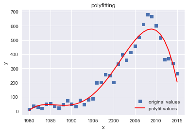

```python
####多项式拟合############
train_x=revenue.head(36).index.values.flatten()
#标签labes
train_y=revenue.head(36).values.flatten()
f1 = np.polyfit(train_x, train_y, 5)
print('拟合的参数 is :\n',f1)
p1 = np.poly1d(f1)
print('多项式为 :\n',p1)
yvals = p1(train_x)
years=[]
for i in range(1980,2016):
    years.append(i)
plot_frame=pd.DataFrame(columns=['Year' ,'predicted_sales','real_sales','difference'])

for i in range(0,36):
    temp_array=[]
    temp_array=np.append(temp_array,years[i])
    temp_array=np.append(temp_array,yvals[i])
    temp_array=np.append(temp_array,train_y[i])
    temp_array=np.append(temp_array,round(np.abs(train_y[i]-yvals[i]),2))
    plot_frame.loc[i]=temp_array


plot1 = plt.plot(train_x, train_y, 's',label='original values')
plot2 = plt.plot(train_x, yvals, 'r',label='polyfit values')
plt.xlabel('x')
plt.ylabel('y')
plt.legend(loc=4) #指定legend的位置右下角
plt.title('polyfitting')
plt.show()
```

**上述为多项式拟合，拟合的多项式公式如上，同时附上拟合的曲线图，下面为每年预测的结果和真实值之间的对比**

```python
print("每年通过三项式预测的结果为(1980~2015):\n")
plot_frame.head(36)
```

[output not shown]

|  | Year | predicted_sales | real_sales | difference |
| --- | --- | --- | --- | --- |
| 0 | 1980.0 | 5.098755 | 11.38 | 6.28 |
| 1 | 1981.0 | 24.548584 | 35.77 | 11.22 |
| 2 | 1982.0 | 36.686279 | 28.86 | 7.83 |
| 3 | 1983.0 | 43.145752 | 16.79 | 26.36 |
| 4 | 1984.0 | 45.454590 | 50.36 | 4.91 |
| 5 | 1985.0 | 45.024902 | 53.94 | 8.92 |
| 6 | 1986.0 | 43.158081 | 37.07 | 6.09 |
| 7 | 1987.0 | 41.032715 | 21.74 | 19.29 |
| 8 | 1988.0 | 39.709106 | 47.22 | 7.51 |
| 9 | 1989.0 | 40.116089 | 73.45 | 33.33 |
| 10 | 1990.0 | 43.058838 | 49.39 | 6.33 |
| 11 | 1991.0 | 49.203735 | 32.23 | 16.97 |
| 12 | 1992.0 | 59.084351 | 76.16 | 17.08 |
| 13 | 1993.0 | 73.092529 | 45.98 | 27.11 |
| 14 | 1994.0 | 91.475952 | 79.17 | 12.31 |
| 15 | 1995.0 | 114.334717 | 88.11 | 26.22 |
| 16 | 1996.0 | 141.616455 | 199.15 | 57.53 |
| 17 | 1997.0 | 173.115723 | 200.98 | 27.86 |
| 18 | 1998.0 | 208.467285 | 256.47 | 48.00 |
| 19 | 1999.0 | 247.144775 | 251.27 | 4.13 |
| 20 | 2000.0 | 288.454712 | 201.56 | 86.89 |
| 21 | 2001.0 | 331.535278 | 331.47 | 0.07 |
| 22 | 2002.0 | 375.351074 | 395.52 | 20.17 |
| 23 | 2003.0 | 418.691162 | 357.85 | 60.84 |
| 24 | 2004.0 | 460.164429 | 414.01 | 46.15 |
| 25 | 2005.0 | 498.194824 | 458.51 | 39.68 |
| 26 | 2006.0 | 531.018799 | 521.04 | 9.98 |
| 27 | 2007.0 | 556.683960 | 609.92 | 53.24 |
| 28 | 2008.0 | 573.038696 | 678.90 | 105.86 |
| 29 | 2009.0 | 577.739136 | 667.30 | 89.56 |
| 30 | 2010.0 | 568.235596 | 600.29 | 32.05 |
| 31 | 2011.0 | 541.775146 | 515.80 | 25.98 |
| 32 | 2012.0 | 495.393677 | 363.49 | 131.90 |
| 33 | 2013.0 | 425.914795 | 368.11 | 57.80 |
| 34 | 2014.0 | 329.947266 | 337.03 | 7.08 |
| 35 | 2015.0 | 203.879517 | 264.44 | 60.56 |

```
高斯拟合的6个参数为:[435.26624927 254.89266263  27.43547532  28.53375571  -8.06297126
   1.79005284]

拟合的曲线如下:
```

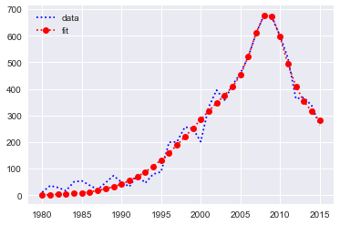

```python
########高斯拟合###############
from scipy.optimize import curve_fit
from scipy import asarray as ar,exp

x = train_x-1980
y = train_y

def gaussian(x,*param):
    return param[0]*np.exp(-np.power(x - param[2], 2.) / (2 * np.power(param[4], 2.)))+param[1]*np.exp(-np.power(x - param[3], 2.) / (2 * np.power(param[5], 2.)))


popt,pcov = curve_fit(gaussian,x,y,p0=[3,4,3,6,1,1])  #p0六个参数分别对应上面*param的六个参数，分别对应两个高斯函数求和。

print("高斯拟合的6个参数为:"+str(popt))
print("\n拟合的曲线如下:")

plt.plot(train_x,y,'b+:',label='data')
plt.plot(train_x,gaussian(x,*popt),'ro:',label='fit')
plt.legend()
plt.show()
```

**从感觉上来看高斯拟合的结果要比多项式拟合的结果效果要好,下面为每年的结果和真实值之间的比较**

```python
print("每年通过高斯拟合预测的结果为(1980~2015):\n")
gauss_frame=pd.DataFrame(columns=['Year' ,'predicted_sales','real_sales','difference'])
gauss_result=gaussian(x,*popt)
for i in range(0,36):
    temp_array2=[]
    temp_array2=np.append(temp_array2,years[i])
    temp_array2=np.append(temp_array2,gauss_result[i])
    temp_array2=np.append(temp_array2,train_y[i])
    temp_array2=np.append(temp_array2,round(np.abs(train_y[i]-gauss_result[i]),2))
    gauss_frame.loc[i]=temp_array2
gauss_frame.head(36)
```

```
每年通过高斯拟合预测的结果为(1980~2015):
```

|  | Year | predicted_sales | real_sales | difference |
| --- | --- | --- | --- | --- |
| 0 | 1980.0 | 1.332347 | 11.38 | 10.05 |
| 1 | 1981.0 | 2.016292 | 35.77 | 33.75 |
| 2 | 1982.0 | 3.004758 | 28.86 | 25.86 |
| 3 | 1983.0 | 4.409458 | 16.79 | 12.38 |
| 4 | 1984.0 | 6.372073 | 50.36 | 43.99 |
| 5 | 1985.0 | 9.067674 | 53.94 | 44.87 |
| 6 | 1986.0 | 12.706643 | 37.07 | 24.36 |
| 7 | 1987.0 | 17.534181 | 21.74 | 4.21 |
| 8 | 1988.0 | 23.826479 | 47.22 | 23.39 |
| 9 | 1989.0 | 31.882618 | 73.45 | 41.57 |
| 10 | 1990.0 | 42.011464 | 49.39 | 7.38 |
| 11 | 1991.0 | 54.513163 | 32.23 | 22.28 |
| 12 | 1992.0 | 69.655382 | 76.16 | 6.50 |
| 13 | 1993.0 | 87.645112 | 45.98 | 41.67 |
| 14 | 1994.0 | 108.597657 | 79.17 | 29.43 |
| 15 | 1995.0 | 132.505204 | 88.11 | 44.40 |
| 16 | 1996.0 | 159.208095 | 199.15 | 39.94 |
| 17 | 1997.0 | 188.372320 | 200.98 | 12.61 |
| 18 | 1998.0 | 219.476876 | 256.47 | 36.99 |
| 19 | 1999.0 | 251.814339 | 251.27 | 0.54 |
| 20 | 2000.0 | 284.508861 | 201.56 | 82.95 |
| 21 | 2001.0 | 316.571600 | 331.47 | 14.90 |
| 22 | 2002.0 | 347.121019 | 395.52 | 48.40 |
| 23 | 2003.0 | 376.291264 | 357.85 | 18.44 |
| 24 | 2004.0 | 407.809562 | 414.01 | 6.20 |
| 25 | 2005.0 | 452.173151 | 458.51 | 6.34 |
| 26 | 2006.0 | 522.026569 | 521.04 | 0.99 |
| 27 | 2007.0 | 611.211342 | 609.92 | 1.29 |
| 28 | 2008.0 | 678.010227 | 678.90 | 0.89 |
| 29 | 2009.0 | 673.540339 | 667.30 | 6.24 |
| 30 | 2010.0 | 596.046417 | 600.29 | 4.24 |
| 31 | 2011.0 | 493.410747 | 515.80 | 22.39 |
| 32 | 2012.0 | 409.917017 | 363.49 | 46.43 |
| 33 | 2013.0 | 354.368270 | 368.11 | 13.74 |
| 34 | 2014.0 | 314.884350 | 337.03 | 22.15 |
| 35 | 2015.0 | 280.675611 | 264.44 | 16.24 |

```python
#使用SVR进行回归测试，将数据以0.8分为训练数据和测试数据

train_x=revenue.head(36).index.values
#标签labes
train_y=revenue.head(36).values
#拆分数据集，建立训练数据集和测试数据集
train_y=train_y.flatten()
from sklearn.cross_validation import train_test_split
from sklearn.linear_model import LogisticRegression
from sklearn import svm
from sklearn.metrics import mean_squared_error
from sklearn.preprocessing import StandardScaler
x_train , x_test , y_train , y_test = train_test_split(train_x ,
                                                      train_y ,
                                                      train_size = .8)
#将测试数据特征转换成二维数组行数*1列
train_x=train_x.reshape(-1,1)
train_y=train_y.reshape(-1,1)
x_train=x_train.reshape(-1, 1)
y_train=y_train.reshape(-1, 1)
x_test=x_test.reshape(-1, 1)
y_test=y_test.reshape(-1, 1)


model = svm.SVR(kernel='linear')
#fit函数训练模型
model.fit(x_train , y_train)

result=model.predict(x_test)

result_all=model.predict(train_x)
mse=mean_squared_error(result,y_test)

train_y=train_y.flatten()
print("测试集上的MSE="+str(mse))

svr_frame=pd.DataFrame(columns=['Year' ,'predicted_sales','real_sales','difference'])
for i in range(0,36):
    temp_array3=[]
    temp_array3=np.append(temp_array3,years[i])
    temp_array3=np.append(temp_array3,result_all[i])
    temp_array3=np.append(temp_array3,train_y[i])
    temp_array3=np.append(temp_array3,round(np.abs(train_y[i]-result_all[i]),2))
    svr_frame.loc[i]=temp_array3
svr_frame.head(36)
```

```
测试集上的MSE=25110.412740085085
```

|  | Year | predicted_sales | real_sales | difference |
| --- | --- | --- | --- | --- |
| 0 | 1980.0 | -107.329545 | 11.38 | 118.71 |
| 1 | 1981.0 | -87.231818 | 35.77 | 123.00 |
| 2 | 1982.0 | -67.134091 | 28.86 | 95.99 |
| 3 | 1983.0 | -47.036364 | 16.79 | 63.83 |
| 4 | 1984.0 | -26.938636 | 50.36 | 77.30 |
| 5 | 1985.0 | -6.840909 | 53.94 | 60.78 |
| 6 | 1986.0 | 13.256818 | 37.07 | 23.81 |
| 7 | 1987.0 | 33.354545 | 21.74 | 11.61 |
| 8 | 1988.0 | 53.452273 | 47.22 | 6.23 |
| 9 | 1989.0 | 73.550000 | 73.45 | 0.10 |
| 10 | 1990.0 | 93.647727 | 49.39 | 44.26 |
| 11 | 1991.0 | 113.745455 | 32.23 | 81.52 |
| 12 | 1992.0 | 133.843182 | 76.16 | 57.68 |
| 13 | 1993.0 | 153.940909 | 45.98 | 107.96 |
| 14 | 1994.0 | 174.038636 | 79.17 | 94.87 |
| 15 | 1995.0 | 194.136364 | 88.11 | 106.03 |
| 16 | 1996.0 | 214.234091 | 199.15 | 15.08 |
| 17 | 1997.0 | 234.331818 | 200.98 | 33.35 |
| 18 | 1998.0 | 254.429545 | 256.47 | 2.04 |
| 19 | 1999.0 | 274.527273 | 251.27 | 23.26 |
| 20 | 2000.0 | 294.625000 | 201.56 | 93.07 |
| 21 | 2001.0 | 314.722727 | 331.47 | 16.75 |
| 22 | 2002.0 | 334.820455 | 395.52 | 60.70 |
| 23 | 2003.0 | 354.918182 | 357.85 | 2.93 |
| 24 | 2004.0 | 375.015909 | 414.01 | 38.99 |
| 25 | 2005.0 | 395.113636 | 458.51 | 63.40 |
| 26 | 2006.0 | 415.211364 | 521.04 | 105.83 |
| 27 | 2007.0 | 435.309091 | 609.92 | 174.61 |
| 28 | 2008.0 | 455.406818 | 678.90 | 223.49 |
| 29 | 2009.0 | 475.504545 | 667.30 | 191.80 |
| 30 | 2010.0 | 495.602273 | 600.29 | 104.69 |
| 31 | 2011.0 | 515.700000 | 515.80 | 0.10 |
| 32 | 2012.0 | 535.797727 | 363.49 | 172.31 |
| 33 | 2013.0 | 555.895455 | 368.11 | 187.79 |
| 34 | 2014.0 | 575.993182 | 337.03 | 238.96 |
| 35 | 2015.0 | 596.090909 | 264.44 | 331.65 |

**从上面可以看出用SVR的效果不好，在测试集上MSE非常大，拟合效果不佳，其原因是作为回归的特征数量不够，这里只是一维，要想效果好，需要多提取写特征**